# Femicides in Italy, an easy solution?

Lately, it seems like everywhere I turn, the buzz is all about femicide and violence against women. The recent tragic murder of Giulia Cecchettin has stirred up quite a storm in Italy—like, a really big one.

*"I mean, isn't working on well-being and the economy enough to reduce femicides? Duh!"*

That was my initial thought—or, more technically, my hypothesis.

So, I did what's probably the only thing one can do to get closer to the truth; I analyzed the correlation between femicides and well-being.

## Findings

Digging into the available data, here's what I've uncovered:

**Unfortunately, a population's economic development doesn't guarantee a decrease in femicides.**

However, more data is needed to reach a conclusion.

Italy is seriously slacking in the international data game. And that's a big problem.

I scoured the depths, and all I could fish out was a dataset on femicides from 2019.

Can you believe it? Femicide is on everyone's lips, but when it comes to concrete data, Italy seems to be playing hide and seek. Quite a conundrum, don't you think?

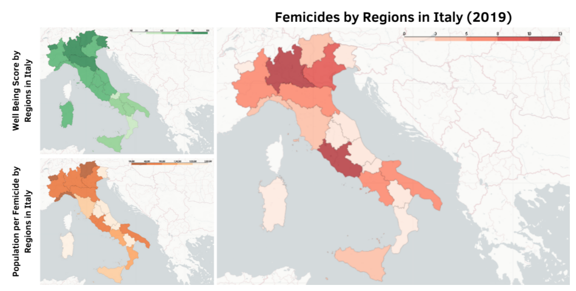

```python
import matplotlib.pyplot as plt
import matplotlib.image as mpimg

fig = plt.figure(figsize=(12, 6))

img = mpimg.imread(r'C:\Users\matte\OneDrive\Desktop\GitHub\data\ita maps\final_ita_maps.png')

plt.imshow(img)
plt.axis('off')
plt.show()
```

## The process

```python
import numpy as np
%matplotlib inline
import seaborn as sns
import matplotlib as mpl
import pandas as pd
import folium
```

```python
df = pd.read_csv(r'C:\Users\matte\OneDrive\Desktop\GitHub\jupyter_storytelling\Data\femm_data.csv')
df.head()
```

|  | Coordinate | 45.67740275700236, 9.17062090859165,45.75673658682066, 12.839683362309302,37.934692602056025, 13.670650963108708,44.86912364667511, 7.735893254727089,40.08763803685724, 18.4087013043204,38.14348202482… |
| --- | --- | --- |
| 0 | Coordinate | 45.67740275700236, 9.17062090859165,45.7567365... |
| 1 | Foto | http://193.205.161.51/ethersheet/images/decd08... |
| 2 | Nome e Fatto | Sharon Barni, di soli 18 mesi, morta a seguito... |
| 3 | Etaˈ | 1,34,14,39,29,32,46,47,49,69,40,90,79,50,42,39... |
| 4 | Nazionalitaˈ | italiana,nigeriana,italiana,italiana,italiana,... |

Check this out! The lone dataset I could get my hands on for femicides is the 2019 one.

And can we just talk about how poorly formatted it is? **U-n-b-e-l-i-e-v-a-b-l-e-!**

### Cleaning the "dataset"

```python
path=r'C:\Users\matte\OneDrive\Desktop\GitHub\jupyter_storytelling\Data\femm_data.csv'

with open(path, 'r') as f:
    lines_list = f.readlines()
```

```python
row1 = lines_list[0]
len(row1.split(','))
```

```
153
```

```python
row2 = lines_list[3]
len(row2.split('.'))
```

```
76
```

```python
row3 = lines_list[4]
row3[:40]
```

```
'"Etaˈ","1,34,14,39,29,32,46,47,49,69,40,'
```

```python
len(row3.split(','))
```

```
77
```

```python
row4 = lines_list[5]
row4[:40]
```

```
'"Nazionalitaˈ","italiana,nigeriana,itali'
```

```python
len(row4.split(','))
```

```
77
```

```python
row5 = lines_list[6]
row5[:40]
```

```
'"Regione","Lombardia,Veneto,Sicilia,Piem'
```

```python
len(row5.split(','))
```

```
77
```

```python
col1 = row1.split(',')
col1.pop(0)
col1[0]
```

```
'"45.67740275700236'
```

```python
col_lat = col1[::2]
col_lat[-1]
```

```
'45.64956780625393'
```

```python
col_lon = col1[1::2]
col_lon[-1]
```

```
' 10.353850889872495"\n'
```

```python
col2 = row2.split('.')
col3 = row3.split(',')
col4 = row4.split(',')
col5 = row5.split(',')
```

```python
col2[0] = col2[0][15:]
col2[0]
```

```
'"Sharon Barni, di soli 18 mesi, morta a seguito dei maltrattamenti e ripetute violenze sessuali da parte del compagno della madre'
```

```python
for i in range(len(col2)):
    try:
        col2[i] = col2[i].strip()
    except AttributeError:
        print(col2[i])
```

```python
col3[0]
```

```
'"Etaˈ"'
```

```python
list_col = [col2, col3, col4, col5, col_lat, col_lon]

for i in list_col:
    for n in range(len(i)):
        i[n] = i[n].strip()
    #list_col[i] = [str(x).strip() for x in list_col[i]]

col3.pop(0)
col4.pop(0)
col5.pop(0)

for col in list_col:
    print(len(col))
```

```
76
76
76
76
76
76
```

```python
data = {
    'lat' : col_lat,
    'lon' : col_lon,
    'facts' : col2,
    'age' : col3,
    'nationality' : col4,
    'region' : col5
}
```

```python
df = pd.DataFrame(data)
df.head()
```

|  | lat | lon | facts | age | nationality | region |
| --- | --- | --- | --- | --- | --- | --- |
| 0 | "45.67740275700236 | 9.17062090859165 | "Sharon Barni, di soli 18 mesi, morta a seguit... | "1 | "italiana | "Lombardia |
| 1 | 45.75673658682066 | 12.839683362309302 | ,Victoria Osagie, uccisa a coltellate dal mari... | 34 | nigeriana | Veneto |
| 2 | 37.934692602056025 | 13.670650963108708 | ,Roberta Siragusa, uccisa dal fidanzato che ha... | 14 | italiana | Sicilia |
| 3 | 44.86912364667511 | 7.735893254727089 | ,Teodora Casasanta, uccisa con corpi contunden... | 39 | italiana | Piemonte |
| 4 | 40.08763803685724 | 18.4087013043204 | ,Sonia Di Maggio, accoltellata e uccisa dal su... | 29 | italiana | Puglia |

```python
for i in df.columns.tolist():
    df[i] = df[i].str.replace('"', '').str.replace("'", "").str.replace(",", "")


df.head()
```

|  | lat | lon | facts | age | nationality | region |
| --- | --- | --- | --- | --- | --- | --- |
| 0 | 45.67740275700236 | 9.17062090859165 | Sharon Barni di soli 18 mesi morta a seguito d... | 1 | italiana | Lombardia |
| 1 | 45.75673658682066 | 12.839683362309302 | Victoria Osagie uccisa a coltellate dal marito... | 34 | nigeriana | Veneto |
| 2 | 37.934692602056025 | 13.670650963108708 | Roberta Siragusa uccisa dal fidanzato che ha c... | 14 | italiana | Sicilia |
| 3 | 44.86912364667511 | 7.735893254727089 | Teodora Casasanta uccisa con corpi contundenti... | 39 | italiana | Piemonte |
| 4 | 40.08763803685724 | 18.4087013043204 | Sonia Di Maggio accoltellata e uccisa dal suo ... | 29 | italiana | Puglia |

```python
df['region'] = df['region'].str.capitalize()

df['region'].value_counts()
```

```
region
Lombardia              13
Lazio                  10
Veneto                  8
Piemonte                6
Puglia                  6
Emilia-romagna          6
Campania                6
Sicilia                 4
Liguria                 4
Trentino-alto adige     3
Toscana                 3
Calabria                2
Emilia romagna          2
Valle daosta            1
Roma                    1
Sardegna                1
Name: count, dtype: int64
```

```python
df.loc[df['region'] == 'Roma', 'region'] = 'Lazio'
df.loc[df['region'] == 'Valle daosta', 'region'] = "Valle d'aosta"
df['region'].value_counts()
```

```
region
Lombardia              13
Lazio                  11
Veneto                  8
Piemonte                6
Puglia                  6
Emilia-romagna          6
Campania                6
Sicilia                 4
Liguria                 4
Trentino-alto adige     3
Toscana                 3
Calabria                2
Emilia romagna          2
Valle d'aosta           1
Sardegna                1
Name: count, dtype: int64
```

## Creating the "Femicides by Regions in Italy" map

```python
df_count_vict = df['region'].value_counts().to_frame()
df_count_vict
```

| region | count |
| --- | --- |
| Lombardia | 13 |
| Lazio | 11 |
| Veneto | 8 |
| Piemonte | 6 |
| Puglia | 6 |
| Emilia-romagna | 6 |
| Campania | 6 |
| Sicilia | 4 |
| Liguria | 4 |
| Trentino-alto adige | 3 |
| Toscana | 3 |
| Calabria | 2 |
| Emilia romagna | 2 |
| Valle d'aosta | 1 |
| Sardegna | 1 |

```python
attr = (
    '&copy; <a href="https://www.openstreetmap.org/copyright">OpenStreetMap</a> '
    'contributors, &copy; <a href="https://cartodb.com/attributions">CartoDB</a>'
)
tiles = "https://{s}.basemaps.cartocdn.com/light_nolabels/{z}/{x}/{y}.png"


ita_map_vict = folium.Map(location=[42,13.5], zoom_start=6, attr=attr, tiles=tiles)
ita_map_vict
```

Make this Notebook Trusted to load map: File -> Trust Notebook

[interactive chart not shown]

```python
ita_map_vict = folium.Map(location=[42,13.5], zoom_start=6, attr=attr, tiles=tiles)

ita_geo = r'C:\Users\matte\OneDrive\Desktop\GitHub\jupyter_storytelling\Data\italy-with-regions_1458.geojson'

ita_map_vict.choropleth(
    geo_data=ita_geo,
    data=df_count_vict,
    columns=[df_count_vict.index, 'count'],
    key_on='feature.properties.name',
    fill_color='Reds',
    fill_opacity=0.7,
    nan_fill_color='#fee0d2',
    line_opacity=0.2,
    threshold_scale=list(np.linspace(0,13,6))
)

ita_map_vict
```

Make this Notebook Trusted to load map: File -> Trust Notebook

[interactive chart not shown]

## Web scraping for more data

```python
from bs4 import BeautifulSoup
import requests
```

```python
link = r'https://facileimmobiliare.it/blog/classifica-qualita-della-vita-2022/'
page = requests.get(link)

soup1 = BeautifulSoup(page.content, 'html.parser')
soup2 = BeautifulSoup(soup1.prettify(), 'html.parser')
rows = soup2.find('tbody').find_all('tr')
```

```python
len(rows)
```

```
108
```

```python
rows = rows[1:]
```

```python
province = []
score = []

for r in rows:
    r2 = r.find_all('td')
    province.append(r2[1].get_text(strip=True))
    score.append(r2[2].get_text(strip=True))
```

```python
print(len(province), len(score))
```

```
107 107
```

```python
data = {'province':province, 'score':score}
df_wb = pd.DataFrame(data)
df_wb
```

|  | province | score |
| --- | --- | --- |
| 0 | Bologna | 590,28 |
| 1 | Bolzano | 585,73 |
| 2 | Firenze | 581,86 |
| 3 | Siena | 578,52 |
| 4 | Trento | 576,62 |
| ... | ... | ... |
| 102 | Vibo Valentia | 405,88 |
| 103 | Foggia | 400,87 |
| 104 | Caltanissetta | 395,63 |
| 105 | Isernia | 391,17 |
| 106 | Crotone | 385,13 |

107 rows × 2 columns

```python
url = 'https://it.wikipedia.org/wiki/Province_d%27Italia'

page = requests.get(url)
```

```python
soup1 = BeautifulSoup(page.content, 'html.parser')
soup2 = BeautifulSoup(soup1.prettify(), 'html.parser')

table = soup2.find('tbody')
```

```python
rows = table.find_all('tr')
rows = rows[1:-1]
```

```python
len(rows)
```

```
107
```

```python
province2 = []
region2 = []
pop2 = []

for r in rows:
    r2 = r.find_all('td')
    province2.append(r2[0].get_text(strip=True))
    region2.append(r2[2].get_text(strip=True))
    pop2.append(r2[3].get_text(strip=True))
```

```python
print(len(region2),len(province2), len(pop2))
```

```
107 107 107
```

```python
data2 = {'province':province2, 'region':region2,'pop':pop2}

df_pop = pd.DataFrame(data2)
df_pop
```

|  | province | region | pop |
| --- | --- | --- | --- |
| 0 | Agrigento[6] | Sicilia | 434 870 |
| 1 | Alessandria | Piemonte | 421 284 |
| 2 | Ancona | Marche | 471 228 |
| 3 | Aosta/Aoste[7] | Valle d'Aosta | 125 666 |
| 4 | Arezzo | Toscana | 342 654 |
| ... | ... | ... | ... |
| 102 | Vercelli | Piemonte | 170 911 |
| 103 | Verona | Veneto | 926 497 |
| 104 | Vibo Valentia | Calabria | 160 073 |
| 105 | Vicenza | Veneto | 862 418 |
| 106 | Viterbo | Lazio | 317 030 |

107 rows × 3 columns

```python
cleaning = df_pop['province'].str.find('[')
```

```python
cleaning = cleaning.replace(-1, np.nan)
```

```python
df_pop['province'] = df_pop['province'].str.extract(r'([^\[]*)')
```

```python
df_wb.head()
```

|  | province | score |
| --- | --- | --- |
| 0 | Bologna | 590,28 |
| 1 | Bolzano | 585,73 |
| 2 | Firenze | 581,86 |
| 3 | Siena | 578,52 |
| 4 | Trento | 576,62 |

```python
df_wb_pop = pd.merge(df_wb, df_pop, on='province', how='outer')
df_wb_pop.loc[(df_wb_pop['score'].isnull() | df_wb_pop['pop'].isnull()), :]
```

|  | province | score | region | pop |
| --- | --- | --- | --- | --- |
| 5 | Aosta | 575,38 | NaN | NaN |
| 22 | Monza-Brianza | 549,62 | NaN | NaN |
| 24 | Pesaro-Urbino | 548,61 | NaN | NaN |
| 62 | L’Aquila | 495,13 | NaN | NaN |
| 107 | Aosta/Aoste | NaN | Valle d'Aosta | 125 666 |
| 108 | L'Aquila | NaN | Abruzzo | 299 031 |
| 109 | Monza e Brianza | NaN | Lombardia | 873 935 |
| 110 | Pesaro e Urbino | NaN | Marche | 351 303 |

```python
df_pop.loc[df_pop['province']=='Aosta/Aoste', 'province'] = 'Aosta'
df_wb.loc[df_wb['province']=="L’Aquila", 'province'] = "L'Aquila"
df_pop.loc[df_pop['province']=='Monza e Brianza', 'province'] = 'Monza-Brianza'
df_pop.loc[df_pop['province']=='Pesaro e Urbino', 'province'] = 'Pesaro-Urbino'
```

```python
df_wb_pop = pd.merge(df_wb, df_pop, on='province', how='outer')
df_wb_pop.tail()
```

|  | province | score | region | pop |
| --- | --- | --- | --- | --- |
| 102 | Vibo Valentia | 405,88 | Calabria | 160 073 |
| 103 | Foggia | 400,87 | Puglia | 622 183 |
| 104 | Caltanissetta | 395,63 | Sicilia | 262 458 |
| 105 | Isernia | 391,17 | Molise | 84 379 |
| 106 | Crotone | 385,13 | Calabria | 174 980 |

## Creating the "Well Being Score by Regions in Italy" map

```python
df_wb_pop['score'] = df_wb_pop['score'].str.replace(',','.').astype('float')
df_wb_pop[['score', 'region']].groupby('region').mean()
```

| region | score |
| --- | --- |
| Abruzzo | 492.945000 |
| Basilicata | 447.265000 |
| Calabria | 411.340000 |
| Campania | 433.258000 |
| Emilia-Romagna | 550.044444 |
| Friuli-Venezia Giulia | 559.550000 |
| Lazio | 486.958000 |
| Liguria | 517.432500 |
| Lombardia | 540.512500 |
| Marche | 520.974000 |
| Molise | 419.745000 |
| Piemonte | 514.237500 |
| Puglia | 440.116667 |
| Sardegna | 488.144000 |
| Sicilia | 430.216667 |
| Toscana | 532.841000 |
| Trentino-Alto Adige | 581.175000 |
| Umbria | 522.220000 |
| Valle d'Aosta | 575.380000 |
| Veneto | 532.687143 |

```python
df_wb_pop['region'] = df_wb_pop['region'].str.capitalize()
df_wb_pop.loc[df_wb_pop['region'] == 'Friuli-venezia giulia', 'region'] = 'Friuli venezia giulia'
```

```python
df_wb_region = df_wb_pop[['score', 'region']].groupby('region').mean()

ita_map_wb = folium.Map(location=[42,13.5], zoom_start=6, attr=attr, tiles=tiles)

ita_geo = r'C:\Users\matte\OneDrive\Desktop\GitHub\jupyter_storytelling\Data\italy-with-regions_1458.geojson'

ita_map_wb.choropleth(
    geo_data=ita_geo,
    data=df_wb_region,
    columns=[df_wb_region.index, 'score'],
    key_on='feature.properties.name',
    fill_color='Greens',
    fill_opacity=0.7,
    line_opacity=0.2,
    threshold_scale=list(np.linspace(300,600,6))
)

ita_map_wb
```

Make this Notebook Trusted to load map: File -> Trust Notebook

[interactive chart not shown]

```python
df_wb_pop.head(1)
```

|  | province | score | region | pop |
| --- | --- | --- | --- | --- |
| 0 | Bologna | 590.28 | Emilia-romagna | 1 017 196 |

## Creating the "Population per Femicide by Regions in Italy" map

```python
df_wb_pop['pop'] = df_wb_pop['pop'].str.replace('\xa0', '').astype('int')
```

```python
df_count_vict
```

| region | count |
| --- | --- |
| Lombardia | 13 |
| Lazio | 11 |
| Veneto | 8 |
| Piemonte | 6 |
| Puglia | 6 |
| Emilia-romagna | 6 |
| Campania | 6 |
| Sicilia | 4 |
| Liguria | 4 |
| Trentino-alto adige | 3 |
| Toscana | 3 |
| Calabria | 2 |
| Emilia romagna | 2 |
| Valle d'aosta | 1 |
| Sardegna | 1 |

```python
df_pop_region = df_wb_pop[['pop', 'region']].groupby('region').sum()
df_pop_region = pd.merge(df_count_vict, df_pop_region, left_index=True, right_index=True)
df_pop_region
```

| region | count | pop |
| --- | --- | --- |
| Lombardia | 13 | 10072132 |
| Lazio | 11 | 5872719 |
| Veneto | 8 | 4904867 |
| Piemonte | 6 | 4354520 |
| Puglia | 6 | 4025548 |
| Emilia-romagna | 6 | 4460835 |
| Campania | 6 | 5789798 |
| Sicilia | 4 | 4985430 |
| Liguria | 4 | 1546887 |
| Trentino-alto adige | 3 | 1072276 |
| Toscana | 3 | 3730699 |
| Calabria | 2 | 1943937 |
| Valle d'aosta | 1 | 125666 |
| Sardegna | 1 | 1638925 |

```python
df_pop_region['abitants_per_vict'] = df_pop_region['pop'] // df_pop_region['count']
df_pop_region
```

| region | count | pop | abitants_per_vict |
| --- | --- | --- | --- |
| Lombardia | 13 | 10072132 | 774779 |
| Lazio | 11 | 5872719 | 533883 |
| Veneto | 8 | 4904867 | 613108 |
| Piemonte | 6 | 4354520 | 725753 |
| Puglia | 6 | 4025548 | 670924 |
| Emilia-romagna | 6 | 4460835 | 743472 |
| Campania | 6 | 5789798 | 964966 |
| Sicilia | 4 | 4985430 | 1246357 |
| Liguria | 4 | 1546887 | 386721 |
| Trentino-alto adige | 3 | 1072276 | 357425 |
| Toscana | 3 | 3730699 | 1243566 |
| Calabria | 2 | 1943937 | 971968 |
| Valle d'aosta | 1 | 125666 | 125666 |
| Sardegna | 1 | 1638925 | 1638925 |

```python
ita_map_pop_vic = folium.Map(location=[42,13.5], zoom_start=6, attr=attr, tiles=tiles)

ita_geo = r'C:\Users\matte\OneDrive\Desktop\GitHub\jupyter_storytelling\Data\italy-with-regions_1458.geojson'

ita_map_pop_vic.choropleth(
    geo_data=ita_geo,
    data=df_pop_region,
    columns=[df_pop_region.index, 'abitants_per_vict'],
    key_on='feature.properties.name',
    fill_color='Oranges_r',
    nan_fill_color='#fee6ce',
    fill_opacity=0.7,
    line_opacity=0.2,
    threshold_scale=list(np.linspace(100000,2000000,6))
)

ita_map_pop_vic
```

Make this Notebook Trusted to load map: File -> Trust Notebook

[interactive chart not shown]